# Exemple de correction du TP Préparation données et estimation des données manquantes

**EL 3016 TP du 16/03/2022 - B.Roudier**

**SOMMAIRE**

[output not shown]

**1. Introduction**

Le prétraitement des données est un ensemble de techniques qui consiste à transformer des données brutes dans un format lisible et compréhensible pour les méthodes d’apprentissage statistiques. Les données réelles sont souvent incomplètes, incohérentes et / ou manquantes et/ ou contenir de nombreuses erreurs. Le prétraitement des données est une phase indispensable avant l’utilisation de méthodes et algorithmes de machinelearning et d’IA. En fonction de la nature et de la qualité des données, elle comprend différentes étapes s’articulant autour des problématiques suivantes :

• La détection des valeurs aberrantes Comme nous l’avons vu dans le cours précédent, l’inclusion de valeurs aberrantes dans un processus d’apprentissage peut avoir de graves répercussions dans l’interprétation des résultats.

• L’estimation des données manquantes La plupart des méthodes et algorithmes d’apprentissage nécessitent des jeux de données complets. Il est donc indispensable d’estimer ces valeurs tout en préservant la distribution de la variable considérée. Il s’agit de méthodes dites ‘d’imputations’. De nombreuses méthodes existent dont certaines sont plus performantes que d’autres. Nous utiliserons dans ce TP des méthodes par remplacement ainsi que des méthodes d’imputations simples (Cold-Deck) par KNN (cf. cours).

• La standardisation des données Il s’agit de rendre «indépendantes» les données de leur grandeur (métrique). En effet, de nombreuses méthodes d’apprentissage nécessitent implicitement ou explicitement le calcul de distances entre des individus ou entre les variables. Si, par exemple, une variable d’un jeu de données est exprimée en mètre (taille d’un individu) et que vous la transformiez en cm (donc x 100), les résultats obtenus risques d’être complétement différents (‘effet loupe’). La standardisation permet de rendre les données indépendantes de leur métrique. Cette partie ne sera pas développée dans ce TP. Elle fera l’objet d’un cours et d’un TP ultérieur.

• Réaliser les statistiques univariées et bivariées Cette partie est indispensable. Elle permet de “comprendre” les données, de “voir” les liens existants entre les différentes variables / individus et leur nature (lineaires, non linéaires).

Elle inclut (au minimum):

• Une estimation des moyennes et quartiles

• Les distributions (histogrammes et densités de probabilité) de chaque variable

• Les correlations entre les variables et les scatter-plots qui permettent de voir la nature des relations existantes (linéaires / non liénaires)

**2. DESCRIPTION DES DONNEES**

- E_MASSE : epaisseur (1 = normal+++ , 10 = normale---)
- UNI_TAILLE : uniformité de taille des cellules (1 = normal+++ , 10 = normale---)
- UNI_FORME : uniformité de la forme des cellules (1 = normal+++ , 10 = normale---)
- ADHESION : adhésion des cellules entre elles et à la couche basales (1 = normal+++ , 10 = normale---)
- TAILLE_EPI : taille de la couche épithèliale sous jacente (1 = normal+++ , 10 = normale---)
- NOYAUX : aspect du noyaux (1 = normal+++ , 10 = normale---)
- CHROMATINE : granule dans le noyau (1 = normal+++ , 10 = normale---)
- NOR_NUCLUS : aspect du nucleus (élement constitutif du noyau) (1 = normal+++ , 10 = normale---)
- MITOSE : division cellulaire (1 = normal+++ , 10 = normale---)
- CLASSE : gold standard = annotation : 2 = Benin - 4 = Malin*

**3. IMPORTATION DES DONNEES**

**3.1 Importation**

3.1.1. Chargement des packages

```python
import os
import numpy as np
import numpy.random as nr
import pandas as pd
import matplotlib.pyplot as plt
import seaborn as sns
from sklearn.impute import SimpleImputer
from sklearn.impute import KNNImputer
import missingno as missviz
```

remarques importantes concernant les packages

• le package os est utilisé pour la gestion des répertoires

• le package sklearn est utilisé pour l’imputation des données. Il s’agit d’un package très important et très utilisé en python (scikit-learn) qui inclut un très grand nombre de méthodes d’apprentissage

• le package missingno est utilisé pour visualiser le positionnement des données manquantes dans un dataframe pour effectuer un diagnostic MAR/MCAR

3.1.2. Chargement du fichier

```python
#A- Dans le cas de jupyter notebook à partir d'Anaconda prompt par exemple
#A.1- cas où le fichier est dans le même répertoire
file = "Breast_MissData.xlsx"
#A.2- cas où le fichier n'est pas dans le répertoire de travail
#donner le chemin pour y accéder
#exemple : file = "C:\MonRep\Breast_MissData.xlsx"

#B- Dans le cas de Google Colab (choix à partir d'une interface GUI)
#from google.colab import files
#uploaded = files.upload()
#file = list(uploaded.keys())[0]

df   = pd.read_excel(file,header = 0, na_values ='')

# La première variable correspond à des identifiants: On la supprime par délétion
df   = df.iloc[:,1:]
# Affichage des 4 premers enregistrements
print(df.head(3))
df   = df.iloc[:,1:]
# Affichage des 4 premers enregistrements
print(df,3)
```

```
Saving Breast_MissData.xlsx to Breast_MissData.xlsx
   E_MASSE  UNI_TAILLE  UNI_FORME  ADHESION  TAILLE_EPITH  NOYAUX  CHROMATINE  \
0      5.0         1.0        NaN       1.0           2.0     NaN         3.0
1      NaN         4.0        4.0       5.0           NaN    10.0         3.0
2      3.0         1.0        1.0       1.0           2.0     NaN         3.0

   NORM_NUCLUS  MITOSES  CLASSE
0          1.0      1.0       2
1          2.0      1.0       2
2          1.0      NaN       2
     UNI_TAILLE  UNI_FORME  ADHESION  TAILLE_EPITH  NOYAUX  CHROMATINE  \
0           1.0        NaN       1.0           2.0     NaN         3.0
1           4.0        4.0       5.0           NaN    10.0         3.0
2           1.0        1.0       1.0           2.0     NaN         3.0
3           8.0        NaN       NaN           NaN     4.0         3.0
```

[output cut: 22 more lines]

**3.2. Transformation de la variable numérique CLASSE en variable catégorielle**

La variable CLASSE est une variable numérique. il convient donc dans un premier temps de modifier les labels (2 et 4) (transformation en variable texte) puis de transfromer cette variable en variable catégorielle. En effet, il est plus facile d’identifier le diagnostic (annotation) des sujets par les labels ’Benin vs Malin" que par 2 et 4

```python
#-> 1. Tranformation en caracteres 4 devient 'Malin' et 2 devient 'Benin'
new_lab = {'CLASSE': {4 : 'Malin' , 2 : 'Benin'} }

#-> 2. Labellisation da la cariable dans le data.frame
df.replace(new_lab, inplace = True)

#-> 3. Transformation character en catégorie de la variable
df['CLASSE'] = df['CLASSE'].astype('category')

#-> 4. On vérifie bien que la variable a été transformée
print(df['CLASSE'].unique())
```

```
['Benin', 'Malin']
Categories (2, object): ['Benin', 'Malin']
```

**4.Valeurs abérrantes**

- Dans un premier temps, on identifie les variables susceptibles de contenir des valeurs abbérantes. Pour y parvenir, on utilise la fonction *describe* qui fournit les statistiques descriptives. A partir de ces dernières, Comment procéderiez vous pour identifier la variable possédant des valeurs (très) abbérantes.
- Confirmer votre choix avec un box plot

```
       UNI_TAILLE   UNI_FORME    ADHESION  TAILLE_EPITH       NOYAUX  \
count  537.000000  530.000000  549.000000    581.000000   563.000000
mean     3.223464    3.271698    2.865209      3.172117    24.733570
std      3.129418    2.990494    2.853486      2.194346   183.090958
min      1.000000    1.000000    1.000000      1.000000     1.000000
25%      1.000000    1.000000    1.000000      2.000000     1.000000
50%      1.000000    2.000000    1.000000      2.000000     1.000000
75%      5.000000    5.000000    4.000000      4.000000     8.000000
max     10.000000   10.000000   10.000000     10.000000  2987.000000

       CHROMATINE  NORM_NUCLUS     MITOSES
count  560.000000   551.000000  570.000000
mean     3.519643     2.794918    1.615789
std      2.504302     3.024694    1.769125
min      1.000000     1.000000    1.000000
25%      2.000000     1.000000    1.000000
50%      3.000000     1.000000    1.000000
75%      5.000000     3.000000    1.000000
max     10.000000    10.000000   10.000000
```

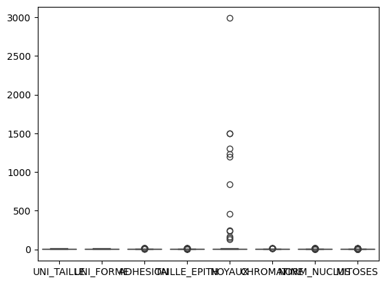

```python
#-> 1.  Statistiques descriptives
dec   = df.describe()
print(dec)

#-> 2. Tracez un simple box plot pour identifier les (la) variable(s) avec
sns.boxplot(data = df)
```

- Comme vous l'avez démontré, la variable *NOYAUX* possède des valeurs abbérantes. On considére que si cette variable est supérieure à 20 alors il s'agit d'une données abbérante. - Ordonner les valeurs par ordre décroissant, - Compter le nombre de valeurs > 20 - remplacer dans le data.frame les valeurs de la variable NOYAUX qui sont supérieures à 20 par des Na

```python
# Sort .. juste pour voir le nombre de données > 20
test_val = df['NOYAUX'].sort_values(ascending = False)
test_val.head(17)
```

|  | NOYAUX |
| --- | --- |
| 321 | 2987.0 |
| 145 | 1500.0 |
| 23 | 1500.0 |
| 139 | 1300.0 |
| 411 | 1230.0 |
| 40 | 1200.0 |
| 249 | 845.0 |
| 617 | 459.0 |
| 164 | 242.0 |
| 315 | 239.0 |
| 292 | 163.0 |
| 297 | 146.0 |
| 235 | 126.0 |
| 263 | 10.0 |
| 251 | 10.0 |
| 252 | 10.0 |
| 253 | 10.0 |

**dtype:** float64

```python
# nombre de données > 20
# idx permet d identifier les lignes ou les valeurs de la varoable NOYAUX sont > 20 DANS le Dataframe ; retourne des booleans
idx   = df['NOYAUX'] > 20 ; print(idx)

nb_ab = idx.sum()
print('\n')
print('nombre de valeur > à 20 = ' + str(nb_ab))
```

```
0      False
1      False
2      False
3      False
4      False
       ...
694    False
695    False
696    False
697    False
698    False
Name: NOYAUX, Length: 699, dtype: bool


nombre de valeur > à 20 = 13
```

```
       UNI_TAILLE   UNI_FORME    ADHESION  TAILLE_EPITH      NOYAUX  \
count  537.000000  530.000000  549.000000    581.000000  550.000000
mean     3.223464    3.271698    2.865209      3.172117    3.614545
std      3.129418    2.990494    2.853486      2.194346    3.706019
min      1.000000    1.000000    1.000000      1.000000    1.000000
25%      1.000000    1.000000    1.000000      2.000000    1.000000
50%      1.000000    2.000000    1.000000      2.000000    1.000000
75%      5.000000    5.000000    4.000000      4.000000    7.000000
max     10.000000   10.000000   10.000000     10.000000   10.000000

       CHROMATINE  NORM_NUCLUS     MITOSES
count  560.000000   551.000000  570.000000
mean     3.519643     2.794918    1.615789
std      2.504302     3.024694    1.769125
min      1.000000     1.000000    1.000000
25%      2.000000     1.000000    1.000000
50%      3.000000     1.000000    1.000000
75%      5.000000     3.000000    1.000000
max     10.000000    10.000000   10.000000
```

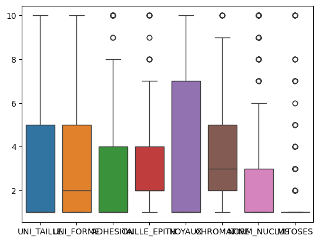

```python
# remplacer dans le dataframe les données abbérantes par des Na (en utilisant les index des lignes)
df.loc[idx,'NOYAUX'] = np.nan

# on pourrait aussi écrire directement
df.loc[df['NOYAUX'] > 20, 'NOYAUX'] = np.nan

# statitiques descriptives
rec_drop = df.describe()
print(rec_drop)
#Tracez un box plot
sns.boxplot(data = df)
```

**5. Données manquantes**  
5.1. Comptage

- Comptez le nombre et le pourcentage de valeurs manquantes par variable
- Comptez le pourcentage et nombre total de valeurs manquantes
- Créer une dataframe que vous appelerez *df_drop* dans laquelle toutes les lignes contenant des valeurs manquantes on été éliminées
- Comparez le nombre d'enregistrement entre *df* et *df_drop*. Que remarque t'on ?

```python
# Nombre de valeurs manquantes et % par variables
[nrow, ncol] = df.shape
print('nombre de valeurs manquantes par variable dans le data.frame')
n_drop  = df.isna().sum() ; print(n_drop)
print('\n')
print('pourcentage de valeurs manquantes par variables')
pc_drop = n_drop / nrow * 100 ; print(pc_drop)
print('\n')

# Nombre de valeurs manquantes et % total
print('nombre total de valeurs manquantes dans le data.frame = ' + str(n_drop.sum()))
print('\n')
print('pourcentage de valeurs manquantes dans le data.frame = ' + str(n_drop.sum() / (nrow * ncol) * 100  ))
```

```
nombre de valeurs manquantes par variable dans le data.frame
UNI_TAILLE      162
UNI_FORME       169
ADHESION        150
TAILLE_EPITH    118
NOYAUX          149
CHROMATINE      139
NORM_NUCLUS     148
MITOSES         129
CLASSE            0
dtype: int64


pourcentage de valeurs manquantes par variables
UNI_TAILLE      23.175966
UNI_FORME       24.177396
ADHESION        21.459227
TAILLE_EPITH    16.881259
NOYAUX          21.316166
CHROMATINE      19.885551
NORM_NUCLUS     21.173104
MITOSES         18.454936
CLASSE           0.000000
dtype: float64


nombre total de valeurs manquantes dans le data.frame = 1164


pourcentage de valeurs manquantes dans le data.frame = 18.502622794468287
```

```python
# Creation du dataframe df_drop
# On élimine toutes les lignes(enregistrements) dont un des éléments ont une valeur NA
df_drop = df.dropna()
[nrow_drop, ncol ] = df_drop.shape
print('nombre d enregistrement de df_drop = ' + str(nrow_drop))
print('nombre d enregistrement de df      = ' + str(nrow))

#Tracez un simple box plot pour identifier les (la) variable(s) avec
#sns.boxplot(data = df_drop)
```

```
nombre d enregistrement de df_drop = 115
nombre d enregistrement de df      = 699
```

5.2. Visualisation des données manquantes Nous utilisons 3 graphiques :

- Visualisation du positionnement des données manquantes dans la dataframe : missviz.matrix(pd.DataFrame(df))
- Visualisation du nombre de données non manquantes par variable :missviz.bar(pd.DataFrame(df))
- Visualisation de la 'relation' entre les variables pour les données manquantes 0 : pas de relation : 1 et -1 : forte relation missviz.heatmap(pd.DataFrame(df))

• Question : D’après le graphique précèdent, quel est selon vous la typologie des données manquantes ?

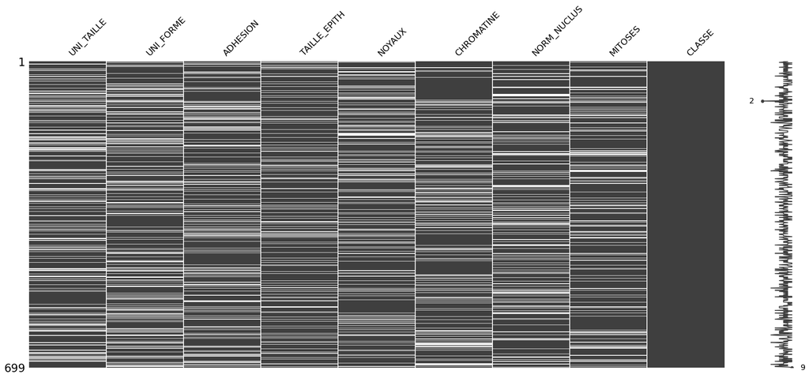

```python
#-> vizualisation positionnement dans la matrice
missviz.matrix(pd.DataFrame(df))
```

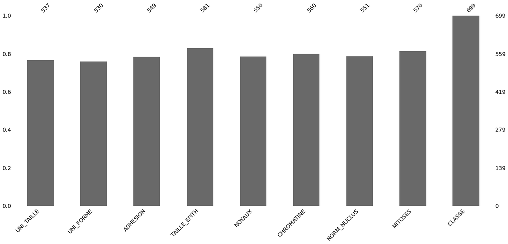

```python
#-> nombre de valeurs non Nan par variable
missviz.bar(pd.DataFrame(df))
```

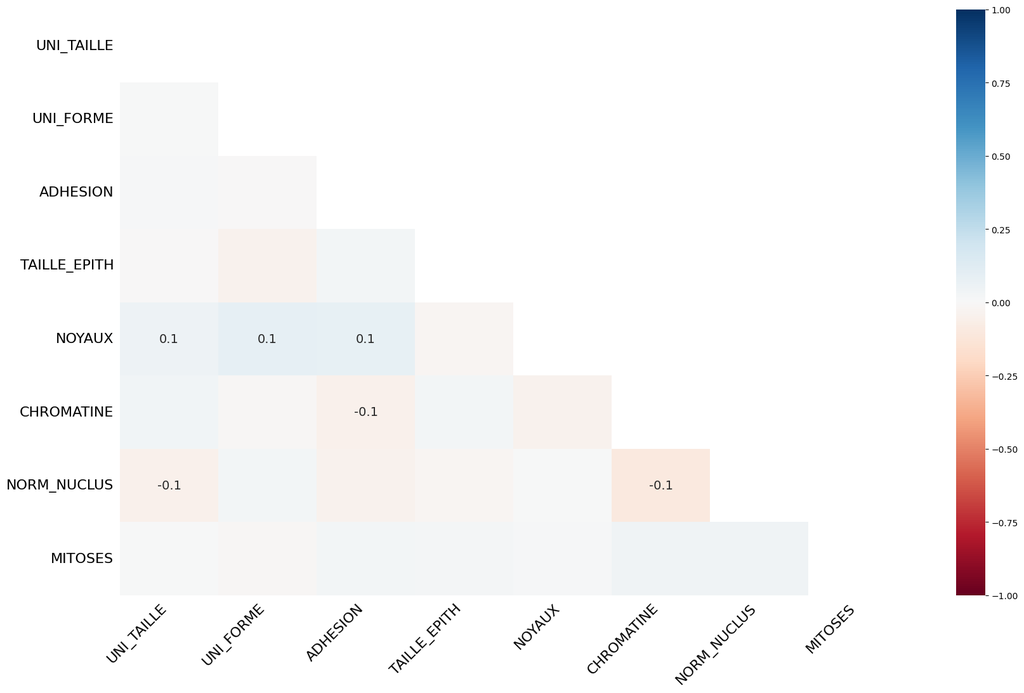

```python
#-> dépendance
missviz.heatmap(pd.DataFrame(df))
```

**5.3. Imputation par une valeur unique dans le cas de variable numérique**

Il s’agit de remplacer toutes les valeurs *numériques* manquantes par une seule valeur qui peut être (i) la moyenne, (ii) la médiane, (iii) la valeur la plus fréquente. Dans un premier temps on crée un dataframe *df_num* dans lequel toutes les variable sont numériques (type float64). ce qui équivaut à éliminer la variable CLASSE

Dans un second temps, on utilise La méthode SimpleImputer (qui est en fait une classe) et qui fonctionne en 3 phases

- on déclare le modèle (appel à un constructeur)
- … puis on effectue l’estimation
- ….puis on impute les données manquantes dans le dataFrame

• Le code suivant effectue les imputations respectivement avec la moyenne, la médiane, et la valeur la plus fréquente

• Pour chaque méthode d’estimation, on calcule les statistiques descriptives puis le coefficient de varition (CV) qui correspond au rapport de la déviation standard à la moyenne. ce ceofficient correspond à la dispertion autour de la tendence centrale. Que remarque-t’on ?

```python
# on crée df_num en sélectionnant uniquement les variables de type : float640
df_num = df.select_dtypes(include = ['float64'])
df_num.head()
```

|  | UNI_TAILLE | UNI_FORME | ADHESION | TAILLE_EPITH | NOYAUX | CHROMATINE | NORM_NUCLUS | MITOSES |
| --- | --- | --- | --- | --- | --- | --- | --- | --- |
| 0 | 1.0 | NaN | 1.0 | 2.0 | NaN | 3.0 | 1.0 | 1.0 |
| 1 | 4.0 | 4.0 | 5.0 | NaN | 10.0 | 3.0 | 2.0 | 1.0 |
| 2 | 1.0 | 1.0 | 1.0 | 2.0 | NaN | 3.0 | 1.0 | NaN |
| 3 | 8.0 | NaN | NaN | NaN | 4.0 | 3.0 | 7.0 | 1.0 |
| 4 | 1.0 | 1.0 | 3.0 | 2.0 | 1.0 | 3.0 | 1.0 | 1.0 |

```
Statistiques déscriptives: Moyenne
                0           1           2           3           4           5  \
count  699.000000  699.000000  699.000000  699.000000  699.000000  699.000000
mean     3.223464    3.271698    2.865209    3.172117    3.614545    3.519643
std      2.742320    2.603413    2.528357    2.000282    3.286746    2.241119
min      1.000000    1.000000    1.000000    1.000000    1.000000    1.000000
25%      1.000000    1.000000    1.000000    2.000000    1.000000    2.000000
50%      3.000000    3.271698    2.000000    2.000000    3.000000    3.000000
75%      3.223464    4.000000    3.000000    3.172117    4.000000    4.000000
max     10.000000   10.000000   10.000000   10.000000   10.000000   10.000000

                6           7
count  699.000000  699.000000
mean     2.794918    1.615789
std      2.684943    1.597302
min      1.000000    1.000000
25%      1.000000    1.000000
50%      1.000000    1.000000
75%      2.794918    1.615789
max     10.000000   10.000000

Coefficients de variation en %
UNI_TAILLE      85.073719
UNI_FORME       79.573750
ADHESION        88.243339
TAILLE_EPITH    63.058276
NOYAUX          90.931099
CHROMATINE      63.674606
NORM_NUCLUS     96.065172
MITOSES         98.855798
dtype: float64
```

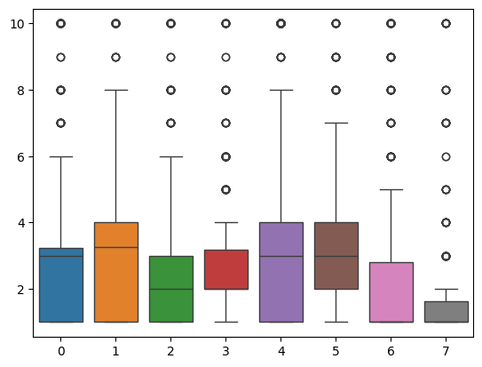

```python
#-> Déclaration du modèle : paramètre la moyenne
fun = SimpleImputer(missing_values = np.nan , strategy = 'mean')
#-> On effectue l'estimation
fun.fit(df_num)
#-> on récupère le dataframe avec les valeurs imputées
df_mean      = pd.DataFrame(fun.transform(df_num))
df_mean_stat = df_mean.describe() ;

print( '\n' + 'Statistiques déscriptives: Moyenne')
print(df_mean_stat)
#-> Calcul des % de variation
#-> df_mean_stat est un objet Panda: on récupère les lignes 1 et 2
mean_CV = df_mean_stat.iloc[2,:] / df_mean_stat.iloc[1,:] *100

print( '\n' + 'Coefficients de variation en %')
mean_CV.index = df_num.columns.tolist()
print(mean_CV)

#Tracez un box plot
sns.boxplot(data = df_mean)
```

```
Statistiques déscriptives : Mediane
                0           1           2           3           4           5  \
count  699.000000  699.000000  699.000000  699.000000  699.000000  699.000000
mean     2.708155    2.964235    2.464950    2.974249    3.057225    3.416309
std      2.898588    2.659821    2.641929    2.047969    3.457004    2.250710
min      1.000000    1.000000    1.000000    1.000000    1.000000    1.000000
25%      1.000000    1.000000    1.000000    2.000000    1.000000    2.000000
50%      1.000000    2.000000    1.000000    2.000000    1.000000    3.000000
75%      3.000000    4.000000    3.000000    3.000000    4.000000    4.000000
max     10.000000   10.000000   10.000000   10.000000   10.000000   10.000000

                6           7
count  699.000000  699.000000
mean     2.414878    1.502146
std      2.783415    1.615091
min      1.000000    1.000000
25%      1.000000    1.000000
50%      1.000000    1.000000
75%      2.000000    1.000000
max     10.000000   10.000000

Coefficients de variation en %
UNI_TAILLE      107.031841
UNI_FORME        89.730464
ADHESION        107.179809
TAILLE_EPITH     68.856689
NOYAUX          113.076540
CHROMATINE       65.881323
NORM_NUCLUS     115.261091
MITOSES         107.518932
dtype: float64
```

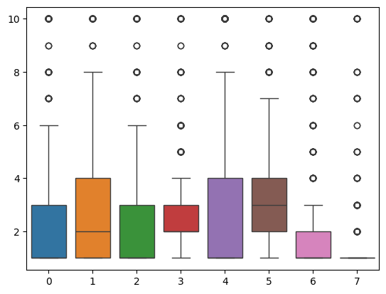

```python
#-> Déclaration du modèle : paramètre la médiane
fun = SimpleImputer(missing_values = np.nan , strategy = 'median')
#-> On effectue l'estimation
fun.fit(df_num)

#-> on récupère le dataframe avec les valeurs imputées
df_median      = pd.DataFrame(fun.transform(df_num))
df_median_stat = df_median.describe()
print( '\n' + 'Statistiques déscriptives : Mediane')
print(df_median_stat)

#-> Calcul des % de variation
#-> df_mean_stat est un objet Panda: on récupère les lignes 1 et 2
median_CV = df_median_stat.iloc[2,:] / df_median_stat.iloc[1,:] *100

print( '\n' + 'Coefficients de variation en %')
median_CV.index = df_num.columns.tolist()
print(median_CV)

#Tracez un box plot
sns.boxplot(data = df_median)
```

```
Statistiques déscriptives : valeur la plus fréquente
                0           1           2           3           4           5  \
count  699.000000  699.000000  699.000000  699.000000  699.000000  699.000000
mean     2.708155    2.722461    2.464950    2.974249    3.057225    3.217454
std      2.898588    2.779416    2.641929    2.047969    3.457004    2.321862
min      1.000000    1.000000    1.000000    1.000000    1.000000    1.000000
25%      1.000000    1.000000    1.000000    2.000000    1.000000    2.000000
50%      1.000000    1.000000    1.000000    2.000000    1.000000    2.000000
75%      3.000000    4.000000    3.000000    3.000000    4.000000    4.000000
max     10.000000   10.000000   10.000000   10.000000   10.000000   10.000000

                6           7
count  699.000000  699.000000
mean     2.414878    1.502146
std      2.783415    1.615091
min      1.000000    1.000000
25%      1.000000    1.000000
50%      1.000000    1.000000
75%      2.000000    1.000000
max     10.000000   10.000000

Coefficients de variation en %
UNI_TAILLE      107.031841
UNI_FORME       102.092057
ADHESION        107.179809
TAILLE_EPITH     68.856689
NOYAUX          113.076540
CHROMATINE       72.164576
NORM_NUCLUS     115.261091
MITOSES         107.518932
dtype: float64
```

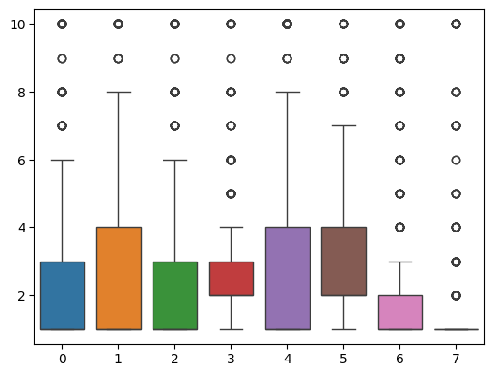

```python
#-> Déclaration du modèle : paramètre la veleur la plus fréquente
fun = SimpleImputer(missing_values = np.nan , strategy = 'most_frequent')
#-> On effectue l'estimation
fun.fit(df_num)
#-> on récupère le dataframe avec les valeurs imputées
df_freq      = pd.DataFrame(fun.transform(df_num))
df_freq_stat = df_freq.describe()

print( '\n' + 'Statistiques déscriptives : valeur la plus fréquente')
print(df_freq_stat)

#-> Calcul des % de variation
#-> df_mean_stat est un objet Panda: on récupère les lignes 1 et 2
freq_CV = df_freq_stat.iloc[2,:] / df_freq_stat.iloc[1,:] *100

print( '\n' + 'Coefficients de variation en %')
freq_CV.index = df_num.columns.tolist()
print(freq_CV)

#Tracez un box plot
sns.boxplot(data = df_freq)
```

• Question : Comparer les CV% entre les 3 méthodes

• Comme on peut le constater, les mêmes programmes sont réalisés 3 fois entrainant un nombre de lignes de code important. Il serait peut être judicieux d’écrire une petite fonction qui encapsule le code par exemple :

```python
def Imputation_Simple(num_ar,miss_val = np.nan, method = 'mean'):
    try:
        fun = SimpleImputer(missing_values = np.nan , strategy = method)
        fun.fit(num_ar) # set
        num_ar_imputed = fun.transform(num_ar)

    except ValueError:
        print("l'argument data n'est pas conforme")
        return(999)
    else:
        return(num_ar_imputed)
```

```python
# Appel de la fonction
# Imputation par la moyenne -->
df_impMean = Imputation_Simple(num_ar = df_num)
# Imputation par la médiane -->
df_impMedian = Imputation_Simple(num_ar = df_num, method = 'median')
# imputation par la valeur la plus féquente -->
df_impMostFreq = Imputation_Simple(num_ar = df_num, method = 'most_frequent')
# et voilà
```

**5.4. Cold-Deck : KNN**

La méthode d’imputation par les K-plus proches voisins est réalisée par une classe qui fonctionne de manière analogue à celle vue pour l’imputation par une valeur unique. La méthode KNNImputer fonctionne aussi en trois étapes + on déclare le modèle; il s’agit de la fonction KNNImputer dans laquelle on assigne le nombre de K plus proches voisins (appel à un constructeur) + … puis on effectue l’estimation + ….puis on impute les données manquantes dans la dataFrame. Le scriptsuivant réalise une imputation avec les 5 plus proches voisins

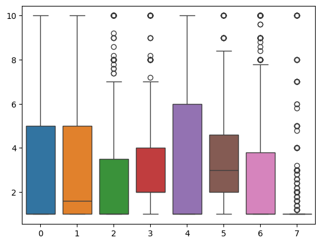

```python
fun = KNNImputer(missing_values = np.nan ,n_neighbors = 5)
fun.fit(df_num)
df_KNN_5   = pd.DataFrame(fun.transform(df_num))
stat_KNN_5 = df_KNN_5.describe()
stat_KNN_5.loc['std',:] / stat_KNN_5 .loc['mean',:] *100

#Tracez un box plot
sns.boxplot(data = df_KNN_5)
```

Réalisez une fonction qui permet de calculer les imputations de manière automatique. Cette fonction retourne un dictionnaire avec les éléments suivants :

- Le data frame des valeurs imputées
- les statistiques descriptives
- les coefficients de variations

```python
# Fonction
def KNN(df, n_ppv):
    fun = KNNImputer(missing_values = np.nan ,n_neighbors = n_ppv)
    fun.fit(df)
    df_out  = pd.DataFrame(fun.transform(df))
    df_out.columns = df.columns.tolist()

    df_stat = df_out.describe()

    df_CV   = df_stat.iloc[2,:] / df_stat.iloc[1,:] *100
    df_CV.index = df.columns.tolist()

    return { 'data' : df_out, 'stat' : df_stat, 'cv' : df_CV  }

result = KNN(df_num,  10)

print(result['data'])
print('\n')
print(result['stat'])
print('\n')
print(result['cv'])
```

```
     UNI_TAILLE  UNI_FORME  ADHESION  TAILLE_EPITH  NOYAUX  CHROMATINE  \
0           1.0        1.1       1.0           2.0     1.0         3.0
1           4.0        4.0       5.0           3.9    10.0         3.0
2           1.0        1.0       1.0           2.0     1.2         3.0
3           8.0        4.2       3.1           5.4     4.0         3.0
4           1.0        1.0       3.0           2.0     1.0         3.0
..          ...        ...       ...           ...     ...         ...
694         1.0        1.5       1.0           3.0     2.0         1.0
695         1.0        1.0       1.2           2.0     1.1         2.4
696        10.0        8.5       3.0           6.3     5.1         8.0
697         8.0        6.0       4.0           3.0     4.0        10.0
698         8.0        8.0       5.0           4.0     5.0        10.0

     NORM_NUCLUS  MITOSES
0            1.0      1.0
1            2.0      1.0
2            1.0      1.0
3            7.0      1.0
4            1.0      1.0
..           ...      ...
694          1.0      1.0
695          1.0      1.0
696         10.0      1.3
697          6.0      1.0
698          4.0      1.0

[699 rows x 8 columns]


       UNI_TAILLE   UNI_FORME    ADHESION  TAILLE_EPITH      NOYAUX  \
count  699.000000  699.000000  699.000000    699.000000  699.000000
mean     3.108584    3.109585    2.774392      3.170959    3.503004
std      2.994907    2.838571    2.700650      2.112726    3.541207
min      1.000000    1.000000    1.000000      1.000000    1.000000
25%      1.000000    1.000000    1.000000      2.000000    1.000000
50%      1.100000    1.500000    1.200000      2.000000    1.000000
75%      5.000000    4.500000    3.800000      4.000000    6.000000
max     10.000000   10.000000   10.000000     10.000000   10.000000

       CHROMATINE  NORM_NUCLUS     MITOSES
count  699.000000   699.000000  699.000000
mean     3.444921     2.799857    1.581116
std      2.383518     2.902837    1.637775
min      1.000000     1.000000    1.000000
25%      2.000000     1.000000    1.000000
50%      3.000000     1.000000    1.000000
75%      4.750000     3.750000    1.000000
max     10.000000    10.000000   10.000000


UNI_TAILLE       96.343135
UNI_FORME        91.284565
ADHESION         97.342062
TAILLE_EPITH     66.627360
NOYAUX          101.090576
CHROMATINE       69.189341
NORM_NUCLUS     103.678039
MITOSES         103.583503
dtype: float64
```

Cette méthode d'imputation pose le problème du choix des k plus proches voisins. Utilisez la fonction pour calculer les valeur imputées avec K = 1, 5, 10, 15, 20, 30, 50 A partir des CV, quelle serait, selon vous le k optimal ?

```python
knn = [1,5,10,15,20,30,50]

c = pd.DataFrame()
for i in knn:
    res = KNN(df_num,  i)
    c   = pd.concat([c, res['cv']], axis = 1)
print(c)
```

```
                       0           0           0           0           0  \
UNI_TAILLE     99.637173   96.228733   96.343135   96.304133   96.177282
UNI_FORME      93.092425   91.403185   91.284565   90.931062   91.069121
ADHESION      103.460104   98.169684   97.342062   97.215869   97.311282
TAILLE_EPITH   68.559596   66.821668   66.627360   66.544872   66.384327
NOYAUX        101.894815  101.649908  101.090576  101.075717  100.884873
CHROMATINE     68.675182   69.485281   69.189341   69.013998   69.171164
NORM_NUCLUS   108.959135  104.399640  103.678039  103.355550  103.298467
MITOSES       106.688338  104.064901  103.583503  103.169543  103.078842

                       0           0
UNI_TAILLE     95.966461   96.082557
UNI_FORME      90.820610   90.702017
ADHESION       97.373059   97.065050
TAILLE_EPITH   66.219588   66.152438
NOYAUX        100.840044  100.860514
CHROMATINE     69.023672   68.941545
NORM_NUCLUS   103.027417  102.725823
MITOSES       102.957739  103.098220
```